# TagLab

Ian Combs – icombs@mote.org

### version: November 08, 2022

#### [GitHub repository](https://github.com/icombs2017/photogrammetryNOAA.git)

This is the analysis pipeline for data generated from TagLab annotations of our 6 10x10m plots.

### All analyses performe with R verion 4.2.1

# Basic setup of R environment

## Loading required packages

For the following analyses we will require the use of a number of different R packages. Most of which can be sourced from CRAN, but some must be downloaded from GitHub. We can use the following code to load in the packages and install any packages not previously installed in the R console.

```r
if (!require("pacman")) install.packages("pacman")
pacman::p_load("ggplot2","officer","ggpubr", "rcompanion", "RColorBrewer", "patchwork", "magrittr","reshape2", "stringr", "plyr", "dplyr", "flextable", "tidyr", "tibble", "vegan", "paletteer")
```

# Loading and Manipulating data

We have loaded a lot of individual data into R and we want to combine the data and create one cohesive dataframe with which to work. In order to do that we have to add a few identifiers to our data frames to hwen combining we can differentiate between the two, but this is also a good time to add other columsn like **treatment** and **time** as well. The majority of this is done using various functions from the package `dplyr`.

```r
sitec1 <- as.factor("c1")
sitec2 <- as.factor("c2")
siteu1 <- as.factor("u1")
siteu2 <- as.factor("u2")
sitez1 <- as.factor("z1")
sitez2 <- as.factor("z2")
pre <- as.factor("Baseline")
post <- as.factor("1 Year")


tagC1Pre <- read.csv("../data/TagLab/2020_08_18_IC-C1.csv", header = T)
tagC1Pre$TagLab.Class.name <- as.factor(tagC1Pre$TagLab.Class.name)
tagC1Pre$TagLab.Date <- as.Date.factor(tagC1Pre$TagLab.Date)

tagC1Pre <- tagC1Pre %>%
  select(TagLab.Date, TagLab.Class.name) %>%
  add_column(sitec1) %>%
  rename(site = sitec1) %>%
  add_column(pre) %>%
  rename(time = pre) %>%
  na.omit() %>%
  group_by(TagLab.Date, TagLab.Class.name, site, time) %>%
  summarise(TagLab.Class.name, n()) %>%
  rename(count = `n()`) %>%
  distinct()
  tagC1Pre$abundance <- (tagC1Pre$count/sum(tagC1Pre$count)*100)
  tagC1Pre <- tagC1Pre %>% arrange(desc(abundance))


tagC1Post <- read.csv("../data/TagLab/2021_12_08_IC-C1.csv", header = T)
tagC1Post$TagLab.Class.name <- as.factor(tagC1Post$TagLab.Class.name)
tagC1Post$TagLab.Date <- as.Date.factor(tagC1Post$TagLab.Date)

tagC1Post <- tagC1Post %>%
  select(TagLab.Date, TagLab.Class.name) %>%
  add_column(sitec1) %>%
  rename(site = sitec1) %>%
  add_column(post) %>%
  rename(time = post) %>%
  na.omit() %>%
  group_by(TagLab.Date, TagLab.Class.name, site, time) %>%
  summarise(TagLab.Class.name, n()) %>%
  rename(count = `n()`) %>%
  distinct()
tagC1Post$abundance <- (tagC1Post$count/sum(tagC1Post$count)*100)
tagC1Post <- tagC1Post %>% arrange(desc(abundance))


tagU1Pre <- read.csv("../data/TagLab/2020_08_19_IC-U1.csv", header = T)
tagU1Pre$TagLab.Class.name <- as.factor(tagU1Pre$TagLab.Class.name)
tagU1Pre$TagLab.Date <- as.Date.factor(tagU1Pre$TagLab.Date)

tagU1Pre <- tagU1Pre %>%
  select(TagLab.Date, TagLab.Class.name) %>%
  add_column(siteu1) %>%
  rename(site = siteu1) %>%
  add_column(pre) %>%
  rename(time = pre) %>%
  na.omit() %>%
  group_by(TagLab.Date, TagLab.Class.name, site, time) %>%
  summarise(TagLab.Class.name, n()) %>%
  rename(count = `n()`) %>%
  distinct()
tagU1Pre$abundance <- (tagU1Pre$count/sum(tagU1Pre$count)*100)
tagU1Pre <- tagU1Pre %>% arrange(desc(abundance))


tagU1Post <- read.csv("../data/TagLab/2021_12_08_IC-U1.csv", header = T)
tagU1Post$TagLab.Class.name <- as.factor(tagU1Post$TagLab.Class.name)
tagU1Post$TagLab.Date <- as.Date.factor(tagU1Post$TagLab.Date)

tagU1Post <- tagU1Post %>%
  select(TagLab.Date, TagLab.Class.name) %>%
  add_column(siteu1) %>%
  rename(site = siteu1) %>%
  add_column(post) %>%
  rename(time = post) %>%
  na.omit() %>%
  group_by(TagLab.Date, TagLab.Class.name, site, time) %>%
  summarise(TagLab.Class.name, n()) %>%
  rename(count = `n()`) %>%
  distinct()
tagU1Post$abundance <- (tagU1Post$count/sum(tagU1Post$count)*100)
tagU1Post <- tagU1Post %>% arrange(desc(abundance))




tag <- bind_rows(tagC1Pre,tagU1Pre,tagC1Post,tagU1Post)
tag <- as_tibble(tag)

tag$treatment = if_else(tag$site %in% c("c2", "z1", "u1"), "Control","Outplanted")
tag$reef = if_else(tag$site %in% c("c1", "c2"), "Site C",
                   if_else(tag$site %in% c("u1", "u2"), "Site U", "Site Z"))
tag$reef <- as.factor(tag$reef)
```

# Checking for Normality

Now that we have the data all in one place with the appropriate columns added, we are going to check to see if our data is normally distributed.

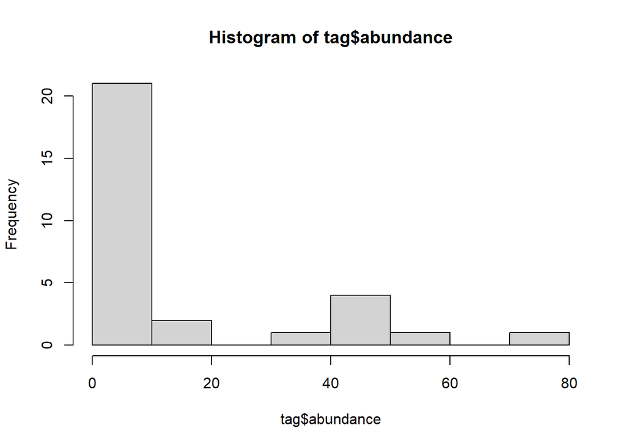

```r
hist(tag$abundance)
```

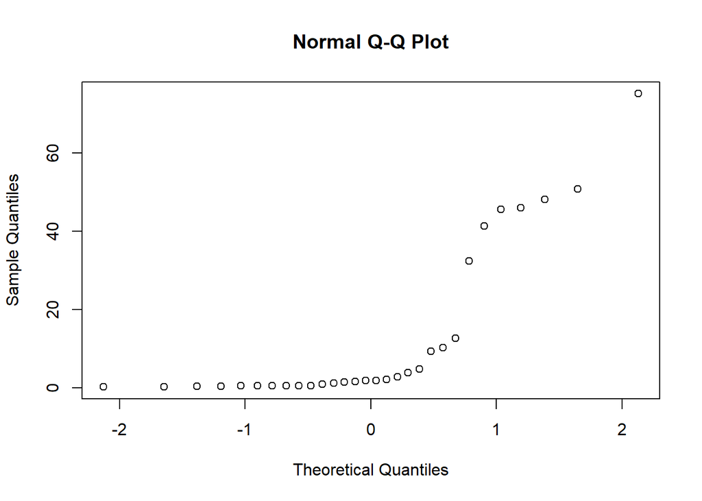

```r
qqnorm(tag$abundance)
```

```r
shapiro.test(tag$abundance)
```

```
##
##  Shapiro-Wilk normality test
##
## data:  tag$abundance
## W = 0.66671, p-value = 5.296e-07
```

# PERMANOVA

```r
tagPerm <- adonis(formula = count ~ time*treatment, data = tag, method = "euclidian", permutations = 9999)
```

```
## 'adonis' will be deprecated: use 'adonis2' instead
```

```r
kruskal.test(abundance ~ treatment, data = tag)
```

```
##
##  Kruskal-Wallis rank sum test
##
## data:  abundance by treatment
## Kruskal-Wallis chi-squared = 0.29244, df = 1, p-value = 0.5887
```

```r
oneYear <- subset(tag, time = "1 Year")
```

# Visualizing Data

We are visualizing the data we just tested for.

```r
myColors <- paletteer_c("pals::ocean.balance", 10, direction = 1)

tag1 <- subset(tag, TagLab.Class.name != "Empty") %>% droplevels()


tag1$TagLab.Class.name = factor(tag1$TagLab.Class.name, levels(tag1$TagLab.Class.name)[c(6,4,1,3,7,2,8,9,5,10)])







tagStack1 <- ggplot(tag1, aes(x = treatment, y = abundance, fill = TagLab.Class.name))+
                      geom_bar(stat = 'identity', color = 'black', position = position_stack(reverse = TRUE), alpha = 0.8)+
                      ylim(0,100)+
                      labs(y = "Relative Abundance (%)", fill = "Class", title = "Relative Species Abundance")+
                      scale_fill_manual(values = myColors)+
                      facet_grid(.~ time)

tagStack <- tagStack1+theme(
    axis.text.x = element_text(size = 40, colour = "black", vjust = 0.5, hjust = 0.5, face= "bold"),
    axis.title.x = element_blank(),
    axis.title.y = element_text(size = 40, face = "bold"),
    axis.text.y = element_text(colour = "black", size = 40, face = "bold"),
    legend.title = element_text(size = 40, face = "bold"),
    legend.text = element_text(size = 30, colour = "black"),
    panel.grid.major = element_line(size = 0.5, linetype = 'solid', colour = "white"),
    panel.background = element_rect(fill = '#F5F5F5'),
    plot.title = element_text(size = 40, face = "bold"),
    axis.line = element_line(colour = "black"),
    axis.ticks = element_line(color="black"),
    text = element_text(size=40, color="black"),
    legend.position = "right")
tagStack

ggsave("../figures/tagStackBar.png", plot = tagStack, width = 20, height = 15, units = 'in', dpi = 600)
ggsave("../figures/tagStackBar.jpeg", plot = tagStack, width = 20, height = 15, units = "in", dpi = 600)
```

[figure not shown]